# stata_INN_Learner_Notebook_Full_code

Bank Churn Prediction

## Problem Statement

### Context

Businesses like banks which provide service have to worry about problem of 'Customer Churn' i.e. customers leaving and joining another service provider. It is important to understand which aspects of the service influence a customer's decision in this regard. Management can concentrate efforts on improvement of service, keeping in mind these priorities.

### Objective

You as a Data scientist with the bank need to build a neural network based classifier that can determine whether a customer will leave the bank or not in the next 6 months.

### Data Dictionary

- CustomerId: Unique ID which is assigned to each customer
- Surname: Last name of the customer
- CreditScore: It defines the credit history of the customer.
- Geography: A customer’s location
- Gender: It defines the Gender of the customer
- Age: Age of the customer
- Tenure: Number of years for which the customer has been with the bank
- NumOfProducts: refers to the number of products that a customer has purchased through the bank.
- Balance: Account balance
- HasCrCard: It is a categorical variable which decides whether the customer has credit card or not.
- EstimatedSalary: Estimated salary
- isActiveMember: Is is a categorical variable which decides whether the customer is active member of the bank or not ( Active member in the sense, using bank products regularly, making transactions etc )
- Exited : whether or not the customer left the bank within six month. It can take two values **0=No ( Customer did not leave the bank )** 1=Yes ( Customer left the bank )

## Importing necessary libraries

```python
# Installing the libraries with the specified version.
!pip install tensorflow==2.15.0 scikit-learn==1.2.2 seaborn==0.13.1 matplotlib==3.7.1 numpy==1.25.2 pandas==2.0.3 imbalanced-learn==0.10.1 shap -q --user
```

```
     ━━━━━━━━━━━━━━━━━━━━━━━━━━━━━━━━━━━━━━━━ 540.5/540.5 kB 8.2 MB/s eta 0:00:00
```

```python
# Libraries to help with reading and manipulating data
import pandas as pd
import numpy as np

import shap

# libaries to help with data visualization
import matplotlib.pyplot as plt
import seaborn as sns

# Library to split data
from sklearn.model_selection import train_test_split

# library to import to standardize the data
from sklearn.preprocessing import StandardScaler, LabelEncoder
from sklearn.preprocessing import MinMaxScaler

# importing different functions to build models
import tensorflow as tf
from tensorflow import keras
from keras import backend
from keras.models import Sequential
from keras.layers import Dense, Dropout

# importing SMOTE
from imblearn.over_sampling import SMOTE

# importing metrics
from sklearn.metrics import confusion_matrix,roc_curve, f1_score,accuracy_score, recall_score, precision_score, classification_report

import random

import time

# Library to avoid the warnings
import warnings
warnings.filterwarnings("ignore")
```

## Loading the dataset

```python
from google.colab import drive
drive.mount('/content/drive')
data_path = "/content/drive/MyDrive/AIML-Certification/AIML-training/Neural Networks/Wk2/Project/Churn.csv"
```

```python
df_orig = pd.read_csv(data_path)
```

## Data Overview

```python
df_orig.head()
```

|  | RowNumber | CustomerId | Surname | CreditScore | Geography | Gender | Age | Tenure | Balance | NumOfProducts | HasCrCard | IsActiveMember | EstimatedSalary | Exited |
| --- | --- | --- | --- | --- | --- | --- | --- | --- | --- | --- | --- | --- | --- | --- |
| 0 | 1 | 15634602 | Hargrave | 619 | France | Female | 42 | 2 | 0.00 | 1 | 1 | 1 | 101348.88 | 1 |
| 1 | 2 | 15647311 | Hill | 608 | Spain | Female | 41 | 1 | 83807.86 | 1 | 0 | 1 | 112542.58 | 0 |
| 2 | 3 | 15619304 | Onio | 502 | France | Female | 42 | 8 | 159660.80 | 3 | 1 | 0 | 113931.57 | 1 |
| 3 | 4 | 15701354 | Boni | 699 | France | Female | 39 | 1 | 0.00 | 2 | 0 | 0 | 93826.63 | 0 |
| 4 | 5 | 15737888 | Mitchell | 850 | Spain | Female | 43 | 2 | 125510.82 | 1 | 1 | 1 | 79084.10 | 0 |

**Observations**:

- Rownumber, CustomerId and Surname can be removed from training dataset
- Geography can be encoded
- 1 hot encoding can be done on Gender

```python
df_orig.tail()
```

|  | RowNumber | CustomerId | Surname | CreditScore | Geography | Gender | Age | Tenure | Balance | NumOfProducts | HasCrCard | IsActiveMember | EstimatedSalary | Exited |
| --- | --- | --- | --- | --- | --- | --- | --- | --- | --- | --- | --- | --- | --- | --- |
| 9995 | 9996 | 15606229 | Obijiaku | 771 | France | Male | 39 | 5 | 0.00 | 2 | 1 | 0 | 96270.64 | 0 |
| 9996 | 9997 | 15569892 | Johnstone | 516 | France | Male | 35 | 10 | 57369.61 | 1 | 1 | 1 | 101699.77 | 0 |
| 9997 | 9998 | 15584532 | Liu | 709 | France | Female | 36 | 7 | 0.00 | 1 | 0 | 1 | 42085.58 | 1 |
| 9998 | 9999 | 15682355 | Sabbatini | 772 | Germany | Male | 42 | 3 | 75075.31 | 2 | 1 | 0 | 92888.52 | 1 |
| 9999 | 10000 | 15628319 | Walker | 792 | France | Female | 28 | 4 | 130142.79 | 1 | 1 | 0 | 38190.78 | 0 |

```python
df_orig.info()
```

```
<class 'pandas.core.frame.DataFrame'>
RangeIndex: 10000 entries, 0 to 9999
Data columns (total 14 columns):
 #   Column           Non-Null Count  Dtype
---  ------           --------------  -----
 0   RowNumber        10000 non-null  int64
 1   CustomerId       10000 non-null  int64
 2   Surname          10000 non-null  object
 3   CreditScore      10000 non-null  int64
 4   Geography        10000 non-null  object
 5   Gender           10000 non-null  object
 6   Age              10000 non-null  int64
 7   Tenure           10000 non-null  int64
 8   Balance          10000 non-null  float64
 9   NumOfProducts    10000 non-null  int64
 10  HasCrCard        10000 non-null  int64
 11  IsActiveMember   10000 non-null  int64
 12  EstimatedSalary  10000 non-null  float64
 13  Exited           10000 non-null  int64
dtypes: float64(2), int64(9), object(3)
memory usage: 1.1+ MB
```

Observations-

- A few object type data has found and need to apply encoding

```python
df_orig.describe(include="all").T
```

|  | count | unique | top | freq | mean | std | min | 25% | 50% | 75% | max |
| --- | --- | --- | --- | --- | --- | --- | --- | --- | --- | --- | --- |
| RowNumber | 10000.0 | NaN | NaN | NaN | 5000.5 | 2886.89568 | 1.0 | 2500.75 | 5000.5 | 7500.25 | 10000.0 |
| CustomerId | 10000.0 | NaN | NaN | NaN | 15690940.5694 | 71936.186123 | 15565701.0 | 15628528.25 | 15690738.0 | 15753233.75 | 15815690.0 |
| Surname | 10000 | 2932 | Smith | 32 | NaN | NaN | NaN | NaN | NaN | NaN | NaN |
| CreditScore | 10000.0 | NaN | NaN | NaN | 650.5288 | 96.653299 | 350.0 | 584.0 | 652.0 | 718.0 | 850.0 |
| Geography | 10000 | 3 | France | 5014 | NaN | NaN | NaN | NaN | NaN | NaN | NaN |
| Gender | 10000 | 2 | Male | 5457 | NaN | NaN | NaN | NaN | NaN | NaN | NaN |
| Age | 10000.0 | NaN | NaN | NaN | 38.9218 | 10.487806 | 18.0 | 32.0 | 37.0 | 44.0 | 92.0 |
| Tenure | 10000.0 | NaN | NaN | NaN | 5.0128 | 2.892174 | 0.0 | 3.0 | 5.0 | 7.0 | 10.0 |
| Balance | 10000.0 | NaN | NaN | NaN | 76485.889288 | 62397.405202 | 0.0 | 0.0 | 97198.54 | 127644.24 | 250898.09 |
| NumOfProducts | 10000.0 | NaN | NaN | NaN | 1.5302 | 0.581654 | 1.0 | 1.0 | 1.0 | 2.0 | 4.0 |
| HasCrCard | 10000.0 | NaN | NaN | NaN | 0.7055 | 0.45584 | 0.0 | 0.0 | 1.0 | 1.0 | 1.0 |
| IsActiveMember | 10000.0 | NaN | NaN | NaN | 0.5151 | 0.499797 | 0.0 | 0.0 | 1.0 | 1.0 | 1.0 |
| EstimatedSalary | 10000.0 | NaN | NaN | NaN | 100090.239881 | 57510.492818 | 11.58 | 51002.11 | 100193.915 | 149388.2475 | 199992.48 |
| Exited | 10000.0 | NaN | NaN | NaN | 0.2037 | 0.402769 | 0.0 | 0.0 | 0.0 | 0.0 | 1.0 |

```python
df_orig.isnull().sum()
```

```
RowNumber          0
CustomerId         0
Surname            0
CreditScore        0
Geography          0
Gender             0
Age                0
Tenure             0
Balance            0
NumOfProducts      0
HasCrCard          0
IsActiveMember     0
EstimatedSalary    0
Exited             0
dtype: int64
```

Observation-

- No nulls have found

```python
df_orig.isna().sum()
```

```
RowNumber          0
CustomerId         0
Surname            0
CreditScore        0
Geography          0
Gender             0
Age                0
Tenure             0
Balance            0
NumOfProducts      0
HasCrCard          0
IsActiveMember     0
EstimatedSalary    0
Exited             0
dtype: int64
```

```python
# check for nulls in surname
for i in df_orig.columns:
  print(f"+++++++++++++++++++++ {i} +++++++++++++++++++++")
  print(f"the num of nulls for column- {i} is -> {df_orig[i].isnull().sum()}")
  print(f"the num of nunique for column- {i} is -> {df_orig[i].nunique()}")
  print(f"the num of value_counts for column- {i} is -> {df_orig[i].value_counts()}")
```

[output not shown]

[output cut: 118 more lines]

```
182692.80    1
            ..
120893.07    1
188377.21    1
55902.93     1
4523.74      1
38190.78     1
Name: count, Length: 9999, dtype: int64
+++++++++++++++++++++ Exited +++++++++++++++++++++
the num of nulls for column- Exited is -> 0
the num of nunique for column- Exited is -> 2
the num of value_counts for column- Exited is -> Exited
0    7963
1    2037
Name: count, dtype: int64
```

## Exploratory Data Analysis

### Univariate Analysis

```python
df_orig.info()
```

```
<class 'pandas.core.frame.DataFrame'>
RangeIndex: 10000 entries, 0 to 9999
Data columns (total 14 columns):
 #   Column           Non-Null Count  Dtype
---  ------           --------------  -----
 0   RowNumber        10000 non-null  int64
 1   CustomerId       10000 non-null  int64
 2   Surname          10000 non-null  object
 3   CreditScore      10000 non-null  int64
 4   Geography        10000 non-null  object
 5   Gender           10000 non-null  object
 6   Age              10000 non-null  int64
 7   Tenure           10000 non-null  int64
 8   Balance          10000 non-null  float64
 9   NumOfProducts    10000 non-null  int64
 10  HasCrCard        10000 non-null  int64
 11  IsActiveMember   10000 non-null  int64
 12  EstimatedSalary  10000 non-null  float64
 13  Exited           10000 non-null  int64
dtypes: float64(2), int64(9), object(3)
memory usage: 1.1+ MB
```

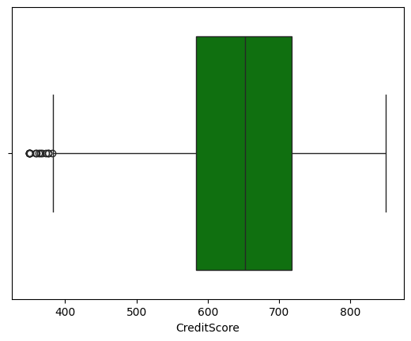

```python
# check for creditScore distribution
sns.boxplot(data=df_orig, x='CreditScore',color='green');
```

Observation- Good number of outliers have been found, we will need outlier treatment for this column

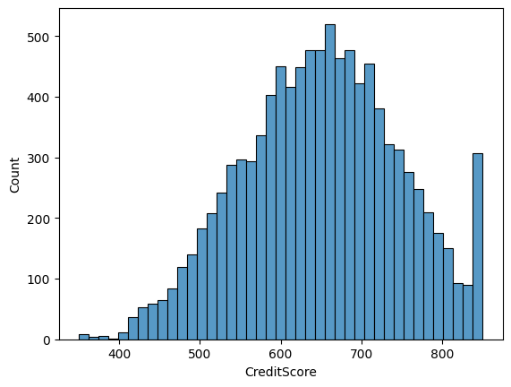

```python
sns.histplot(data=df_orig, x='CreditScore');
```

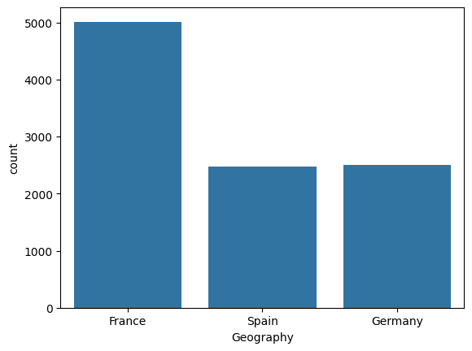

```python
# counts for Geography
sns.countplot(data=df_orig, x='Geography');
```

Observation-

- Pretty much no obeservation here, may need 1 hot encoding to treat categorical values

```python
df_orig.columns
```

```
Index(['RowNumber', 'CustomerId', 'Surname', 'CreditScore', 'Geography',
       'Gender', 'Age', 'Tenure', 'Balance', 'NumOfProducts', 'HasCrCard',
       'IsActiveMember', 'EstimatedSalary', 'Exited'],
      dtype='object')
```

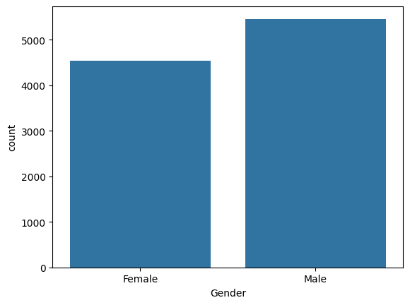

```python
# Gender counts
sns.countplot(data=df_orig, x='Gender');
```

Observation-

- should undergo for one hot encoding

```python
# visualize the numerical attributes distribution
numerical_cols = df_orig.select_dtypes(include=['number']).columns
```

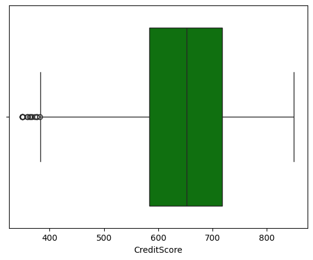

```python
sns.boxplot(data=df_orig, x='CreditScore',color='green')
```

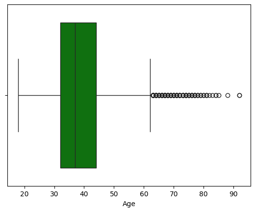

```python
sns.boxplot(data=df_orig, x='Age',color='green')
```

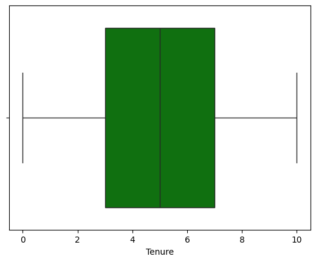

```python
sns.boxplot(data=df_orig, x='Tenure',color='green')
```

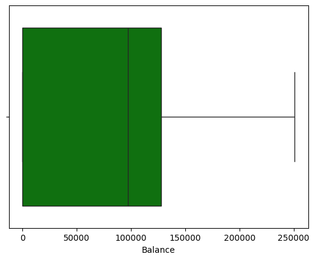

```python
sns.boxplot(data=df_orig, x='Balance',color='green')
```

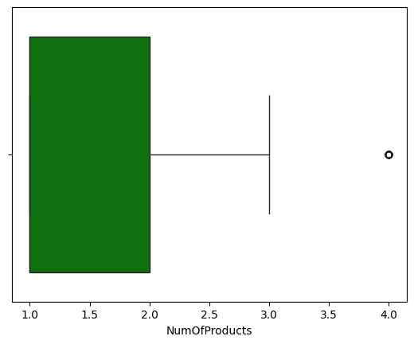

```python
sns.boxplot(data=df_orig, x='NumOfProducts',color='green')
```

Observation-

- Number of products and balance are facts and I am not intended to mask or modify data on this

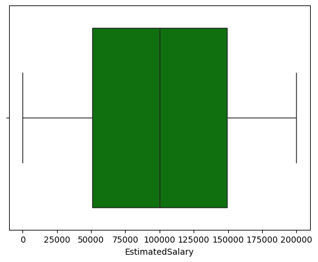

```python
sns.boxplot(data=df_orig, x='EstimatedSalary',color='green')
```

### Bivariate Analysis

```python
df_orig.info()
```

```
<class 'pandas.core.frame.DataFrame'>
RangeIndex: 10000 entries, 0 to 9999
Data columns (total 14 columns):
 #   Column           Non-Null Count  Dtype
---  ------           --------------  -----
 0   RowNumber        10000 non-null  int64
 1   CustomerId       10000 non-null  int64
 2   Surname          10000 non-null  object
 3   CreditScore      10000 non-null  int64
 4   Geography        10000 non-null  object
 5   Gender           10000 non-null  object
 6   Age              10000 non-null  int64
 7   Tenure           10000 non-null  int64
 8   Balance          10000 non-null  float64
 9   NumOfProducts    10000 non-null  int64
 10  HasCrCard        10000 non-null  int64
 11  IsActiveMember   10000 non-null  int64
 12  EstimatedSalary  10000 non-null  float64
 13  Exited           10000 non-null  int64
dtypes: float64(2), int64(9), object(3)
memory usage: 1.1+ MB
```

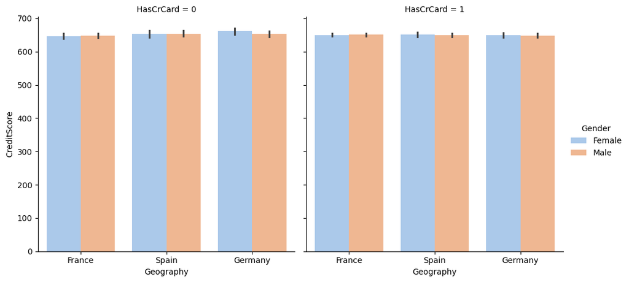

```python
# Check for geography and creditscore
# sns.catplot(data=df_orig, x='Geography', y='CreditScore');
sns.catplot(data=df_orig, x="Geography", y="CreditScore", hue="Gender", col="HasCrCard", kind='bar', palette='pastel');
```

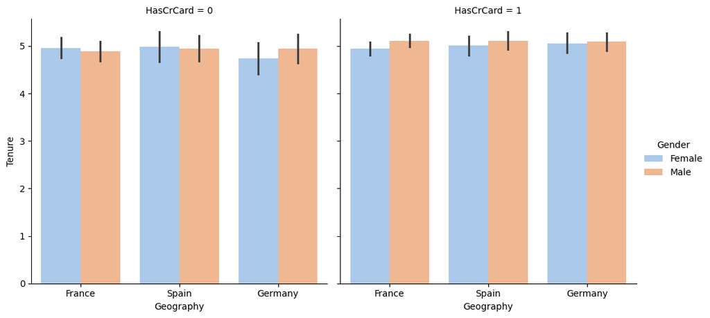

```python
sns.catplot(data=df_orig, x="Geography", y="Tenure", hue="Gender", col="HasCrCard", kind='bar', palette='pastel');
```

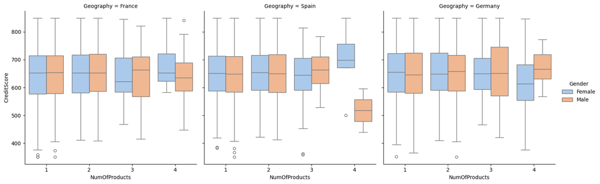

```python
sns.catplot(data=df_orig, x="NumOfProducts", y="CreditScore", hue="Gender", col="Geography", kind='box', palette='pastel');
```

Observation-

- in spain- when number of products increase then it has different credit score for female

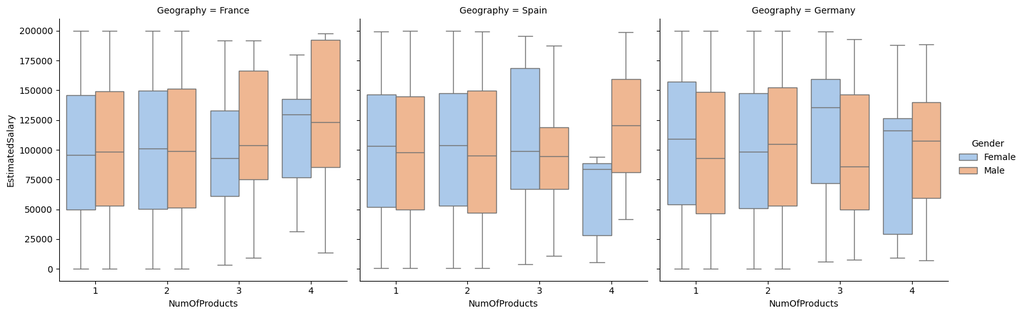

```python
sns.catplot(data=df_orig, x="NumOfProducts", y="EstimatedSalary", hue="Gender", col="Geography", kind='box', palette='pastel');
```

Observation-

- for customers with more than 2 products has diffrent salary

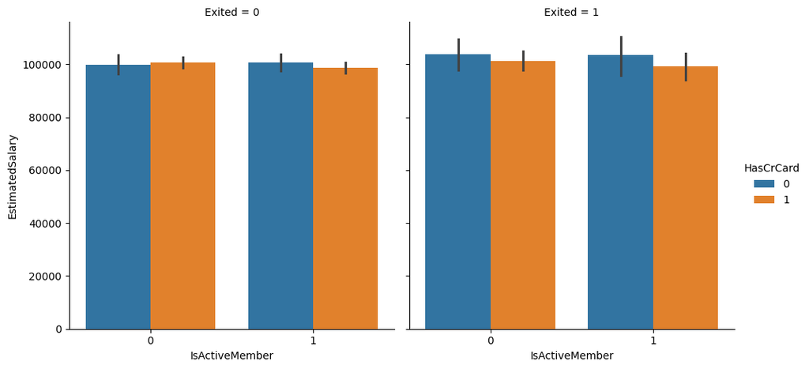

```python
sns.catplot(data=df_orig, x='IsActiveMember', y='EstimatedSalary', hue='HasCrCard', col='Exited', kind='bar');
```

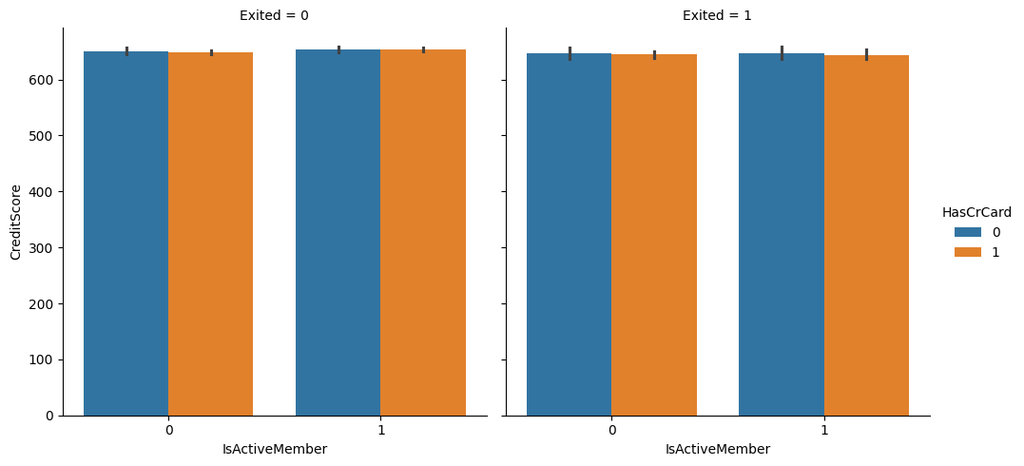

```python
sns.catplot(data=df_orig, x='IsActiveMember', y='CreditScore', hue='HasCrCard', col='Exited', kind='bar');
```

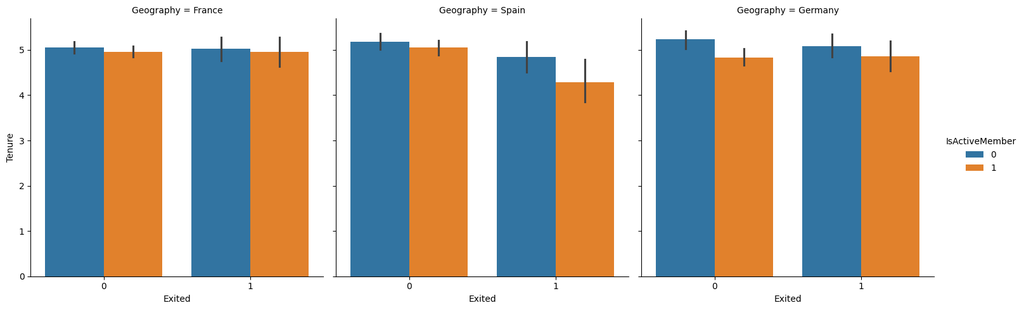

```python
sns.catplot(data=df_orig, x='Exited', y='Tenure', hue='IsActiveMember', col='Geography', kind='bar');
```

Observation- In spain and germany a little vairation has been found with exited numbers based on active status

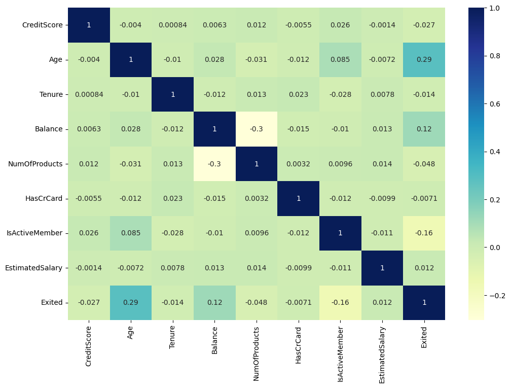

```python
plt.figure(figsize=(12, 8))
sns.heatmap(data=df_orig[['CreditScore','Age', 'Tenure'
, 'Balance', 'NumOfProducts', 'HasCrCard',
       'IsActiveMember', 'EstimatedSalary', 'Exited']].corr(), annot=True, cmap='YlGnBu');
```

Observatins-

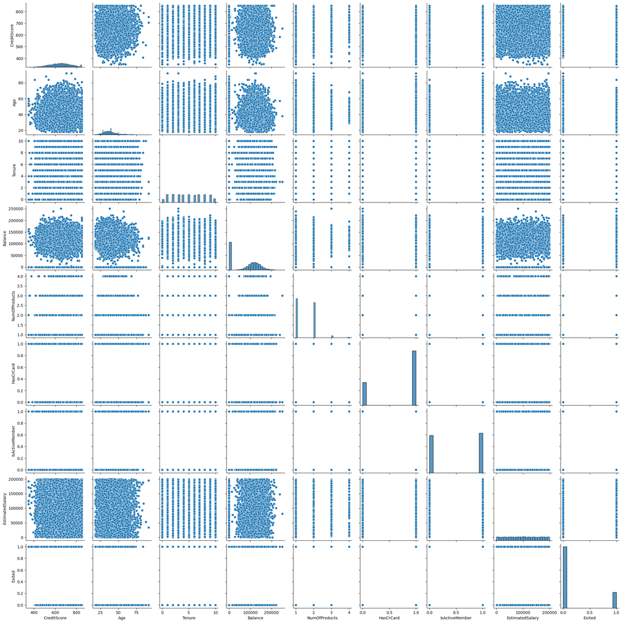

```python
sns.pairplot(data=df_orig[['CreditScore','Age', 'Tenure'
, 'Balance', 'NumOfProducts', 'HasCrCard',
       'IsActiveMember', 'EstimatedSalary', 'Exited']]);
```

Observations- From above plot I donot see any linear relations, however just poking on observations

## Data Preprocessing

### Dummy Variable Creation

```python
# remove attributes that are not required
df = df_orig.drop(['RowNumber', 'CustomerId', 'Surname'], axis=1)
```

```python
# one hot encoding for geography- I am thinking the predictions
# would matter based on geo locations hence I am ensuring no cardinal relations based on locations
df = pd.get_dummies(df, columns=['Geography'])
```

```python
df = pd.get_dummies(df, columns=['Gender'])
```

```python
df.info()
```

```
<class 'pandas.core.frame.DataFrame'>
RangeIndex: 10000 entries, 0 to 9999
Data columns (total 14 columns):
 #   Column             Non-Null Count  Dtype
---  ------             --------------  -----
 0   CreditScore        10000 non-null  int64
 1   Age                10000 non-null  int64
 2   Tenure             10000 non-null  int64
 3   Balance            10000 non-null  float64
 4   NumOfProducts      10000 non-null  int64
 5   HasCrCard          10000 non-null  int64
 6   IsActiveMember     10000 non-null  int64
 7   EstimatedSalary    10000 non-null  float64
 8   Exited             10000 non-null  int64
 9   Geography_France   10000 non-null  bool
 10  Geography_Germany  10000 non-null  bool
 11  Geography_Spain    10000 non-null  bool
 12  Gender_Female      10000 non-null  bool
 13  Gender_Male        10000 non-null  bool
dtypes: bool(5), float64(2), int64(7)
memory usage: 752.1 KB
```

```python
def convert_dtypes(df):
    # Convert float64 to float32
    float_cols = df.select_dtypes(include=['float64']).columns
    df[float_cols] = df[float_cols].astype('float32')

    # Convert int64 to int32
    int_cols = df.select_dtypes(include=['int64']).columns
    df[int_cols] = df[int_cols].astype('int32')

    bool_cols = df.select_dtypes(include=['bool']).columns
    df[bool_cols] = df[bool_cols].astype('int32')
    return df
```

```python
df_conv = convert_dtypes(df)
```

```python
df_conv.info()
```

```
<class 'pandas.core.frame.DataFrame'>
RangeIndex: 10000 entries, 0 to 9999
Data columns (total 14 columns):
 #   Column             Non-Null Count  Dtype
---  ------             --------------  -----
 0   CreditScore        10000 non-null  int32
 1   Age                10000 non-null  int32
 2   Tenure             10000 non-null  int32
 3   Balance            10000 non-null  float32
 4   NumOfProducts      10000 non-null  int32
 5   HasCrCard          10000 non-null  int32
 6   IsActiveMember     10000 non-null  int32
 7   EstimatedSalary    10000 non-null  float32
 8   Exited             10000 non-null  int32
 9   Geography_France   10000 non-null  int32
 10  Geography_Germany  10000 non-null  int32
 11  Geography_Spain    10000 non-null  int32
 12  Gender_Female      10000 non-null  int32
 13  Gender_Male        10000 non-null  int32
dtypes: float32(2), int32(12)
memory usage: 547.0 KB
```

##### outlier treatment for creditscore

```python
def treat_outliers(df, col):
    """
    treats outliers in a variable
    col: str, name of the numerical variable
    df: dataframe
    col: name of the column
    """
    Q1 = df[col].quantile(0.25)  # 25th quantile
    Q3 = df[col].quantile(0.75)  # 75th quantile
    IQR = Q3 - Q1                # Inter Quantile Range (75th perentile - 25th percentile)
    lower_whisker = Q1 - 1.5 * IQR
    upper_whisker = Q3 + 1.5 * IQR

    # all the values smaller than lower_whisker will be assigned the value of lower_whisker
    # all the values greater than upper_whisker will be assigned the value of upper_whisker
    # the assignment will be done by using the clip function of NumPy
    df[col] = np.clip(df[col], lower_whisker, upper_whisker)

    return df
```

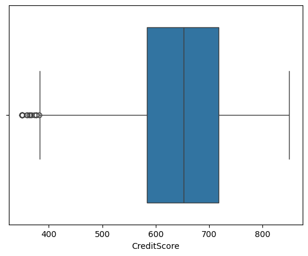

```python
# values before treatment
sns.boxplot(df, x = 'CreditScore')
```

```python
df = treat_outliers(df, 'CreditScore')
```

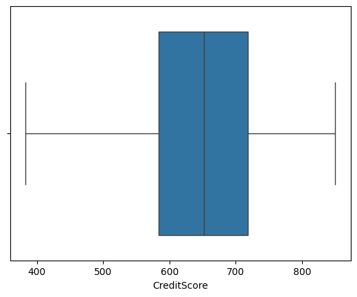

```python
# check if outliers have properly treated
sns.boxplot(df, x = 'CreditScore')
```

### Train-validation-test Split

```python
features = df.drop(['Exited'], axis=1)
features.info()
```

```
<class 'pandas.core.frame.DataFrame'>
RangeIndex: 10000 entries, 0 to 9999
Data columns (total 13 columns):
 #   Column             Non-Null Count  Dtype
---  ------             --------------  -----
 0   CreditScore        10000 non-null  int32
 1   Age                10000 non-null  int32
 2   Tenure             10000 non-null  int32
 3   Balance            10000 non-null  float32
 4   NumOfProducts      10000 non-null  int32
 5   HasCrCard          10000 non-null  int32
 6   IsActiveMember     10000 non-null  int32
 7   EstimatedSalary    10000 non-null  float32
 8   Geography_France   10000 non-null  int32
 9   Geography_Germany  10000 non-null  int32
 10  Geography_Spain    10000 non-null  int32
 11  Gender_Female      10000 non-null  int32
 12  Gender_Male        10000 non-null  int32
dtypes: float32(2), int32(11)
memory usage: 507.9 KB
```

```python
target = df['Exited']
target.info()
```

```
<class 'pandas.core.series.Series'>
RangeIndex: 10000 entries, 0 to 9999
Series name: Exited
Non-Null Count  Dtype
--------------  -----
10000 non-null  int32
dtypes: int32(1)
memory usage: 39.2 KB
```

```python
# Splitting the dataset into the Training and Test set.
X_train, X_test, y_train, y_test = train_test_split(features,target, test_size = 0.2, random_state = 42,stratify = target)
```

```python
# Splitting the Train dataset into the Training and Validation set.
X_train, X_val, y_train, y_val = train_test_split(X_train,y_train, test_size = 0.2, random_state = 42,stratify = y_train)
```

```python
#Printing the shape of the dataset.
print(X_train.shape)
print(y_train.shape)
print(X_test.shape)
print(y_test.shape)
print(X_val.shape)
print(y_val.shape)
```

```
(6400, 13)
(6400,)
(2000, 13)
(2000,)
(1600, 13)
(1600,)
```

```python
# check for any data type issues/any other null nan related issues with in dataframe
for i in [X_train, y_train, X_val, y_val]:
  if np.any(np.isnan(i)) or np.any(np.isinf(i)):
      print("Array contains NaN or Inf values")
  else:
      print("Array is clean")
```

```
Array is clean
Array is clean
Array is clean
Array is clean
```

```python
print(X_train.info())
print(y_train.info())
print(X_test.info())
print(y_test.info())
print(X_val.info())
print(y_val.info())
```

```
<class 'pandas.core.frame.DataFrame'>
Index: 6400 entries, 3006 to 1558
Data columns (total 13 columns):
 #   Column             Non-Null Count  Dtype
---  ------             --------------  -----
 0   CreditScore        6400 non-null   int32
 1   Age                6400 non-null   int32
 2   Tenure             6400 non-null   int32
 3   Balance            6400 non-null   float32
 4   NumOfProducts      6400 non-null   int32
 5   HasCrCard          6400 non-null   int32
 6   IsActiveMember     6400 non-null   int32
 7   EstimatedSalary    6400 non-null   float32
 8   Geography_France   6400 non-null   int32
 9   Geography_Germany  6400 non-null   int32
 10  Geography_Spain    6400 non-null   int32
 11  Gender_Female      6400 non-null   int32
 12  Gender_Male        6400 non-null   int32
dtypes: float32(2), int32(11)
memory usage: 375.0 KB
None
<class 'pandas.core.series.Series'>
Index: 6400 entries, 3006 to 1558
Series name: Exited
Non-Null Count  Dtype
--------------  -----
6400 non-null   int32
dtypes: int32(1)
memory usage: 75.0 KB
None
<class 'pandas.core.frame.DataFrame'>
Index: 2000 entries, 5702 to 3776
Data columns (total 13 columns):
 #   Column             Non-Null Count  Dtype
---  ------             --------------  -----
 0   CreditScore        2000 non-null   int32
 1   Age                2000 non-null   int32
 2   Tenure             2000 non-null   int32
 3   Balance            2000 non-null   float32
 4   NumOfProducts      2000 non-null   int32
```

[output cut: 35 more lines]

```
 10  Geography_Spain    1600 non-null   int32
 11  Gender_Female      1600 non-null   int32
 12  Gender_Male        1600 non-null   int32
dtypes: float32(2), int32(11)
memory usage: 93.8 KB
None
<class 'pandas.core.series.Series'>
Index: 1600 entries, 7140 to 5566
Series name: Exited
Non-Null Count  Dtype
--------------  -----
1600 non-null   int32
dtypes: int32(1)
memory usage: 18.8 KB
None
```

### Data Normalization

```python
#Standardizing the numerical variables to zero mean and unit variance.
def normalizer(df):
  numeric_cols = [i for i in df.select_dtypes(include='number') if i != 'Exited']
  print(numeric_cols)
  transformer = StandardScaler()
  df[numeric_cols] = transformer.fit_transform(df[numeric_cols])
  return df


X_train = normalizer(X_train)
X_val = normalizer(X_val)
X_test = normalizer(X_test)
```

```
['CreditScore', 'Age', 'Tenure', 'Balance', 'NumOfProducts', 'HasCrCard', 'IsActiveMember', 'EstimatedSalary', 'Geography_France', 'Geography_Germany', 'Geography_Spain', 'Gender_Female', 'Gender_Male']
['CreditScore', 'Age', 'Tenure', 'Balance', 'NumOfProducts', 'HasCrCard', 'IsActiveMember', 'EstimatedSalary', 'Geography_France', 'Geography_Germany', 'Geography_Spain', 'Gender_Female', 'Gender_Male']
['CreditScore', 'Age', 'Tenure', 'Balance', 'NumOfProducts', 'HasCrCard', 'IsActiveMember', 'EstimatedSalary', 'Geography_France', 'Geography_Germany', 'Geography_Spain', 'Gender_Female', 'Gender_Male']
```

```python
#Printing the shape of the dataset.
print(X_train.shape)
print(X_val.shape)
print(X_test.shape)
```

```
(6400, 13)
(1600, 13)
(2000, 13)
```

```python
X_train.info()
```

```
<class 'pandas.core.frame.DataFrame'>
Index: 6400 entries, 3006 to 1558
Data columns (total 13 columns):
 #   Column             Non-Null Count  Dtype
---  ------             --------------  -----
 0   CreditScore        6400 non-null   float64
 1   Age                6400 non-null   float64
 2   Tenure             6400 non-null   float64
 3   Balance            6400 non-null   float64
 4   NumOfProducts      6400 non-null   float64
 5   HasCrCard          6400 non-null   float64
 6   IsActiveMember     6400 non-null   float64
 7   EstimatedSalary    6400 non-null   float64
 8   Geography_France   6400 non-null   float64
 9   Geography_Germany  6400 non-null   float64
 10  Geography_Spain    6400 non-null   float64
 11  Gender_Female      6400 non-null   float64
 12  Gender_Male        6400 non-null   float64
dtypes: float64(13)
memory usage: 700.0 KB
```

```python
X_val.info()
```

```
<class 'pandas.core.frame.DataFrame'>
Index: 1600 entries, 7140 to 5566
Data columns (total 13 columns):
 #   Column             Non-Null Count  Dtype
---  ------             --------------  -----
 0   CreditScore        1600 non-null   float64
 1   Age                1600 non-null   float64
 2   Tenure             1600 non-null   float64
 3   Balance            1600 non-null   float64
 4   NumOfProducts      1600 non-null   float64
 5   HasCrCard          1600 non-null   float64
 6   IsActiveMember     1600 non-null   float64
 7   EstimatedSalary    1600 non-null   float64
 8   Geography_France   1600 non-null   float64
 9   Geography_Germany  1600 non-null   float64
 10  Geography_Spain    1600 non-null   float64
 11  Gender_Female      1600 non-null   float64
 12  Gender_Male        1600 non-null   float64
dtypes: float64(13)
memory usage: 175.0 KB
```

```python
X_test.info()
```

```
<class 'pandas.core.frame.DataFrame'>
Index: 2000 entries, 5702 to 3776
Data columns (total 13 columns):
 #   Column             Non-Null Count  Dtype
---  ------             --------------  -----
 0   CreditScore        2000 non-null   float64
 1   Age                2000 non-null   float64
 2   Tenure             2000 non-null   float64
 3   Balance            2000 non-null   float64
 4   NumOfProducts      2000 non-null   float64
 5   HasCrCard          2000 non-null   float64
 6   IsActiveMember     2000 non-null   float64
 7   EstimatedSalary    2000 non-null   float64
 8   Geography_France   2000 non-null   float64
 9   Geography_Germany  2000 non-null   float64
 10  Geography_Spain    2000 non-null   float64
 11  Gender_Female      2000 non-null   float64
 12  Gender_Male        2000 non-null   float64
dtypes: float64(13)
memory usage: 218.8 KB
```

## Model Building

### Model Evaluation Criterion

```python
def make_confusion_matrix(actual_targets, predicted_targets):
    """
    To plot the confusion_matrix with percentages

    actual_targets: actual target (dependent) variable values
    predicted_targets: predicted target (dependent) variable values
    """
    cm = confusion_matrix(actual_targets, predicted_targets)
    labels = np.asarray(
        [
            ["{0:0.0f}".format(item) + "\n{0:.2%}".format(item / cm.flatten().sum())]
            for item in cm.flatten()
        ]
    ).reshape(cm.shape[0], cm.shape[1])

    plt.figure(figsize=(6, 4))
    sns.heatmap(cm, annot=labels, fmt="")
    plt.ylabel("True label")
    plt.xlabel("Predicted label")
```

```python
train_metric_df = pd.DataFrame(columns=["recall"])
valid_metric_df = pd.DataFrame(columns=["recall"])
```

```python
def plot(history, name):
    """
    Function to plot loss/accuracy

    history: an object which stores the metrics and losses.
    name: can be one of Loss or Accuracy
    """
    fig, ax = plt.subplots() #Creating a subplot with figure and axes.
    plt.plot(history.history[name]) #Plotting the train accuracy or train loss
    plt.plot(history.history['val_'+name]) #Plotting the validation accuracy or validation loss

    plt.title('Model ' + name.capitalize()) #Defining the title of the plot.
    plt.ylabel(name.capitalize()) #Capitalizing the first letter.
    plt.xlabel('Epoch') #Defining the label for the x-axis.
    fig.legend(['Train', 'Validation'], loc="outside right upper") #Defining the legend, loc controls the position of the legend.
```

```python
# defining a function to compute different metrics to check performance of a classification model built using statsmodels
def model_performance_classification(
    model, predictors, target, threshold=0.5
):
    """
    Function to compute different metrics to check classification model performance

    model: classifier
    predictors: independent variables
    target: dependent variable
    threshold: threshold for classifying the observation as class 1
    """

    # checking which probabilities are greater than threshold
    pred = model.predict(predictors) > threshold
    # pred_temp = model.predict(predictors) > threshold
    # # rounding off the above values to get classes
    # pred = np.round(pred_temp)

    acc = accuracy_score(target, pred)  # to compute Accuracy
    recall = recall_score(target, pred, average='weighted')  # to compute Recall
    precision = precision_score(target, pred, average='weighted')  # to compute Precision
    f1 = f1_score(target, pred, average='weighted')  # to compute F1-score

    # creating a dataframe of metrics
    df_perf = pd.DataFrame(
        {"Accuracy": acc, "Recall": recall, "Precision": precision, "F1 Score": f1,},
        index=[0],
    )

    return df_perf
```

```python
# Define metrics to be used
# metrics = ['accuracy', keras.metrics.Recall(), keras.metrics.Precision(), keras.metrics.F1Score()]
from keras.metrics import Precision, Recall, F1Score
metrics = ['accuracy', Precision(name='precision'), Recall(name='recall'), F1Score(name='F1Score')]
```

```python
batch_size = 32
epochs = 100
```

### Neural Network with SGD Optimizer

```python
# Below confs are crashing the session
batch_size = 32
epochs = 100
```

```python
# Base model with 1 input and 2 hidden and 1 output layer
# relu and tanh activations will be used for first and second hidden
# clearing keras session
tf.keras.backend.clear_session()
np.random.seed(2)
random.seed(2)
tf.random.set_seed(2)
```

```python
# set up NN (Neural network)
model_1 = Sequential()
model_1.add(Dense(128,activation="relu",input_dim = X_train.shape[1]))
model_1.add(Dense(64,activation="tanh"))
model_1.add(Dense(1,activation = 'sigmoid'))
```

```python
# optimizer initialization
# Defining SGD with learning rate 0.001
optimizer = keras.optimizers.SGD(0.001)
model_1.compile(loss="binary_crossentropy", optimizer=optimizer, metrics = [keras.metrics.Recall()])

# getting unexpected issues when metrics were defined, hence keeping it aside for now
# , metrics = metrics
```

```python
model_1.summary()
```

[output not shown]

```python
import time
start = time.time()
history1 = model_1.fit(X_train, y_train, validation_data=(X_val,y_val), batch_size=batch_size, epochs=epochs)
end=time.time()
```

```python
print("Time taken in seconds ",end-start)
```

[output not shown]

```python
plot(history1,'loss')
```

[output not shown]

```python
plot(history1,'recall')
```

[output not shown]

```python
# Predicting the results using y_train
y_train_pred = model_1.predict(X_train)
y_train_pred = (y_train_pred > 0.5)
y_train_pred
```

[output not shown]

```python
# Predicting the results using validation dataset
y_val_pred = model_1.predict(X_val)
y_val_pred = (y_val_pred > 0.5)
y_val_pred
```

[output not shown]

```python
model_name = "NN with SGD"

train_metric_df.loc[model_name] = recall_score(y_train, y_train_pred)
valid_metric_df.loc[model_name] = recall_score(y_val, y_val_pred)
```

#### Classification report

```python
# report for train
from sklearn.metrics import classification_report
classification_report = classification_report(y_train, y_train_pred)
print(classification_report)
```

[output not shown]

```python
# report for val
from sklearn.metrics import classification_report
classification_report=classification_report(y_val, y_val_pred)
print(classification_report)
```

[output not shown]

#### Confusion matrix

```python
make_confusion_matrix(y_train, y_train_pred)
```

[output not shown]

```python
make_confusion_matrix(y_val, y_val_pred)
```

[output not shown]

```python
# check for model performance
model_1_train_perf = model_performance_classification(model_1, X_train, y_train)
model_1_train_perf
```

[output not shown]

```python
model_1_valid_perf = model_performance_classification(model_1, X_val, y_val)
model_1_valid_perf
```

[output not shown]

## Model Performance Improvement

### Neural Network with Adam Optimizer

```python
tf.keras.backend.clear_session()
np.random.seed(2)
random.seed(2)
tf.random.set_seed(2)

model_2 = Sequential()
model_2.add(Dense(128,activation="relu",input_dim = X_train.shape[1]))
model_2.add(Dense(64,activation="tanh"))
model_2.add(Dense(1,activation = 'sigmoid'))
model_2.summary()
```

```
Model: "sequential"
_________________________________________________________________
 Layer (type)                Output Shape              Param #
=================================================================
 dense (Dense)               (None, 128)               1792

 dense_1 (Dense)             (None, 64)                8256

 dense_2 (Dense)             (None, 1)                 65

=================================================================
Total params: 10113 (39.50 KB)
Trainable params: 10113 (39.50 KB)
Non-trainable params: 0 (0.00 Byte)
_________________________________________________________________
```

```python
optimizer = keras.optimizers.Adam()
model_2.compile(loss="binary_crossentropy", optimizer=optimizer, metrics=[keras.metrics.Recall()])
```

```python
import time
start = time.time()
history2 = model_2.fit(X_train, y_train, validation_data=(X_val,y_val), batch_size=batch_size, epochs=epochs)
end=time.time()
```

```python
print("Time taken in seconds ",end-start)
```

```
Time taken in seconds  82.5642409324646
```

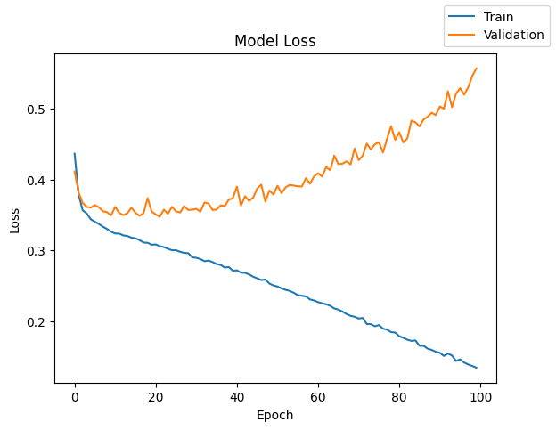

```python
plot(history2,'loss')
```

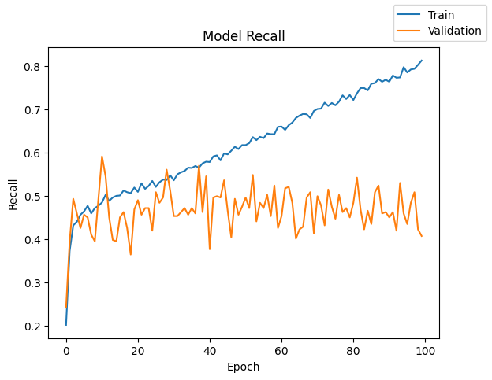

```python
plot(history2,'recall')
```

```python
# Predicting the results using y_train
y_train_pred = model_2.predict(X_train)
y_train_pred = (y_train_pred > 0.5)
y_train_pred
```

```
array([[ True],
       [False],
       [False],
       ...,
       [False],
       [ True],
       [False]])
```

```python
# Predicting the results using validation dataset
y_val_pred = model_2.predict(X_val)
y_val_pred = (y_val_pred > 0.5)
y_val_pred
```

```
array([[False],
       [False],
       [False],
       ...,
       [False],
       [False],
       [False]])
```

```python
# add metrics to a DF for final comparision
model_name = "NN with ADAM"
train_metric_df.loc[model_name] = recall_score(y_train, y_train_pred)
valid_metric_df.loc[model_name] = recall_score(y_val, y_val_pred)
```

#### Classification report

```python
# report for train
from sklearn.metrics import classification_report
classification_report = classification_report(y_train, y_train_pred)
print(classification_report)
```

```
              precision    recall  f1-score   support

           0       0.95      0.99      0.97      5096
           1       0.97      0.78      0.86      1304

    accuracy                           0.95      6400
   macro avg       0.96      0.88      0.92      6400
weighted avg       0.95      0.95      0.95      6400
```

During trainings- the precission recall and f1 scores are at peak for 0 type, seems to be this model is a overfit

```python
# report for val
from sklearn.metrics import classification_report
classification_report=classification_report(y_val, y_val_pred)
print(classification_report)
```

```
              precision    recall  f1-score   support

           0       0.86      0.94      0.90      1274
           1       0.65      0.41      0.50       326

    accuracy                           0.83      1600
   macro avg       0.76      0.68      0.70      1600
weighted avg       0.82      0.83      0.82      1600
```

the scores are relatively good for value "0" with validation data- clost to train but value"1" has heavy deviation and its a good indication of model overfit

#### Confusion matrix

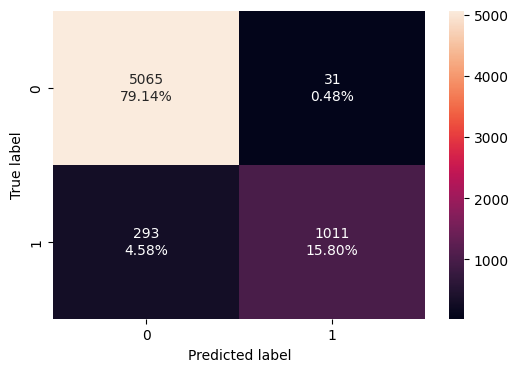

```python
make_confusion_matrix(y_train, y_train_pred)
```

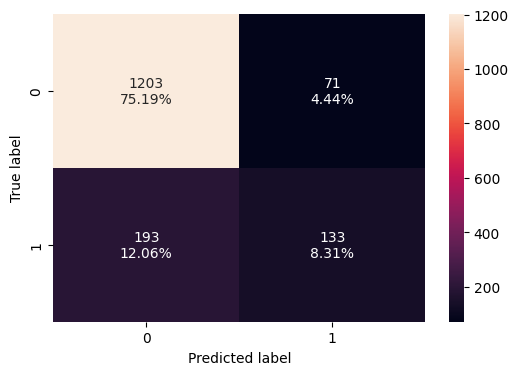

```python
make_confusion_matrix(y_val, y_val_pred)
```

```python
# check for model performance
model_2_train_perf = model_performance_classification(model_2, X_train, y_train)
model_2_train_perf
```

|  | Accuracy | Recall | Precision | F1 Score |
| --- | --- | --- | --- | --- |
| 0 | 0.949375 | 0.949375 | 0.950396 | 0.947183 |

```python
# check for model performance
model_2_train_perf = model_performance_classification(model_2, X_val, y_val)
model_2_train_perf
```

|  | Accuracy | Recall | Precision | F1 Score |
| --- | --- | --- | --- | --- |
| 0 | 0.835 | 0.835 | 0.819004 | 0.819779 |

The train data on this model has good metrics where as the validation is not bad but we can expect more improvement from other models

### Neural Network with Adam Optimizer and Dropout

```python
tf.keras.backend.clear_session()
np.random.seed(2)
random.seed(2)
tf.random.set_seed(2)

model_3 = Sequential()

model_3.add(Dense(128,activation="relu",input_dim = X_train.shape[1]))
model_3.add(Dropout(0.5))
model_3.add(Dense(64,activation="tanh"))
model_3.add(Dropout(0.5))
model_3.add(Dense(1,activation = 'sigmoid'))
model_3.summary()
```

```
Model: "sequential"
_________________________________________________________________
 Layer (type)                Output Shape              Param #
=================================================================
 dense (Dense)               (None, 128)               1792

 dropout (Dropout)           (None, 128)               0

 dense_1 (Dense)             (None, 64)                8256

 dropout_1 (Dropout)         (None, 64)                0

 dense_2 (Dense)             (None, 1)                 65

=================================================================
Total params: 10113 (39.50 KB)
Trainable params: 10113 (39.50 KB)
Non-trainable params: 0 (0.00 Byte)
_________________________________________________________________
```

```python
optimizer = keras.optimizers.Adam()
model_3.compile(loss="binary_crossentropy", optimizer=optimizer, metrics=[keras.metrics.Recall()])
```

```python
import time
start = time.time()
history3 = model_3.fit(X_train, y_train, validation_data=(X_val,y_val), batch_size=batch_size, epochs=epochs)
end=time.time()
```

```python
print("Time taken in seconds ",end-start)
```

```
Time taken in seconds  80.6320252418518
```

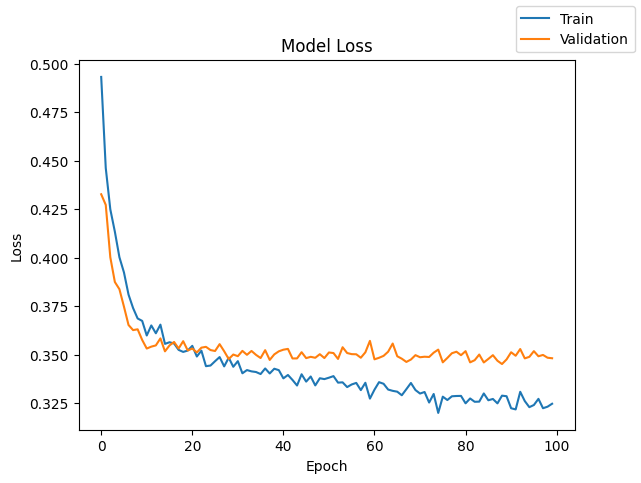

```python
plot(history3,'loss')
```

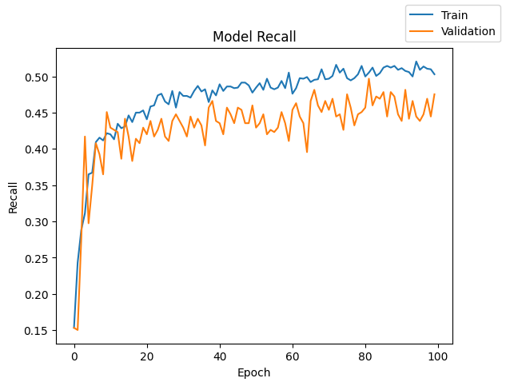

```python
plot(history3,'recall')
```

```python
# Predicting the results using y_train
y_train_pred = model_3.predict(X_train)
y_train_pred = (y_train_pred > 0.5)
y_train_pred
```

```
array([[False],
       [False],
       [False],
       ...,
       [False],
       [ True],
       [False]])
```

```python
# Predicting the results using validation dataset
y_val_pred = model_3.predict(X_val)
y_val_pred = (y_val_pred > 0.5)
y_val_pred
```

```
array([[False],
       [False],
       [False],
       ...,
       [False],
       [ True],
       [ True]])
```

```python
model_name = "NN with ADAM and Dropout"
train_metric_df.loc[model_name] = recall_score(y_train, y_train_pred)
valid_metric_df.loc[model_name] = recall_score(y_val, y_val_pred)
```

#### classification report

```python
# report for train
from sklearn.metrics import classification_report
classification_report = classification_report(y_train, y_train_pred)
print(classification_report)
```

```
              precision    recall  f1-score   support

           0       0.89      0.96      0.93      5096
           1       0.78      0.55      0.64      1304

    accuracy                           0.88      6400
   macro avg       0.84      0.75      0.78      6400
weighted avg       0.87      0.88      0.87      6400
```

```python
# report for val
from sklearn.metrics import classification_report
classification_report=classification_report(y_val, y_val_pred)
print(classification_report)
```

```
              precision    recall  f1-score   support

           0       0.88      0.95      0.91      1274
           1       0.72      0.48      0.57       326

    accuracy                           0.85      1600
   macro avg       0.80      0.71      0.74      1600
weighted avg       0.84      0.85      0.84      1600
```

#### Confusion matrix

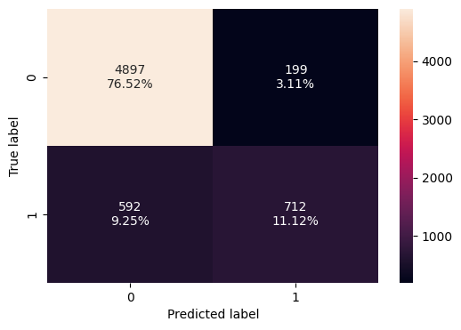

```python
make_confusion_matrix(y_train, y_train_pred)
```

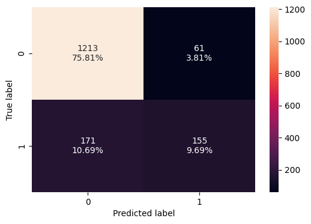

```python
make_confusion_matrix(y_val, y_val_pred)
```

```python
model_3_train_perf = model_performance_classification(model_3, X_train, y_train)
model_3_train_perf
```

|  | Accuracy | Recall | Precision | F1 Score |
| --- | --- | --- | --- | --- |
| 0 | 0.876406 | 0.876406 | 0.869615 | 0.867736 |

```python
model_3_valid_perf = model_performance_classification(model_3, X_val, y_val)
model_3_valid_perf
```

|  | Accuracy | Recall | Precision | F1 Score |
| --- | --- | --- | --- | --- |
| 0 | 0.855 | 0.855 | 0.844079 | 0.843286 |

Model doesnt seems to be an overfit on train model, also it has significant closer metric values with validation data